## How do the seasons affect the success of climbing the Himalayan mountains?

The Himalayan mountains are one of the most famous moutnain ranges in the world with Everest being the most popular due to it being the highest mountain in the world. Mountain climbers or *alpinists* as many of them are called, have been scaling this mountain range for decades and scaling this only seems to have gotten more popular over time. Despite this poularity, climbing the mountain is still an extremely dangerous task and this project will aim to see if there is a noticeably “best” time of the year to attempt to summit this mountain.

**One stipulation** is that the Himalayan mountains do not necessarily have traditional seasons in the way that we understand them with the range instead having a rainy and a dry season. This also varies throughout the mountain range but working within the limits of this data-set we will use the seasons provided to attempt to see trends in the best time of year to go.

# Data Cleaning and Transformation

Firstly I’d like to get a better idea of the data that the project is investigating.

### Termination reason

Lets see how many unique `TERMREASON` values the data-set has so see the total number of reasons why treks usually end.

```r
total_rows <- nrow(exped_raw)
unique_termreason_count <- exped_raw %>%
  summarise(Unique_Number_of_Termination_Reasons = n_distinct(TERMREASON))
unique_termreason_count
```

```
# A tibble: 1 × 1
  Unique_Number_of_Termination_Reasons
                                 <int>
1                                   13
```

Now lets get a better idea of how these reasons are distributed

```r
top_10_termreason <- exped_raw %>%
  count(TERMREASON) %>%
  arrange(desc(n)) %>%
  head(10) %>%
  mutate(percentage = (n / total_rows) * 100)

termreason_table <- top_10_termreason %>%
  gt() %>%
  tab_header(
    title = "Top 10 Termination Reasons"
  ) %>%
  cols_label(TERMREASON = "Termination Reason",
             n = "Occurrence",
             percentage = "Percentage")

termreason_table
```

Top 10 Termination Reasons

| Termination Reason | Occurrence | Percentage |
| --- | --- | --- |
| 1 | 628 | 71.2018141 |
| 4 | 78 | 8.8435374 |
| 5 | 54 | 6.1224490 |
| 2 | 26 | 2.9478458 |
| 7 | 25 | 2.8344671 |
| 0 | 23 | 2.6077098 |
| 12 | 12 | 1.3605442 |
| 14 | 12 | 1.3605442 |
| 10 | 9 | 1.0204082 |
| 6 | 5 | 0.5668934 |

### Now to look at the most popular routes

Lets see how many unique `ROUTE1` values the data-set has to see how many unique routes are taken.

```r
unique_route1_count <- exped_raw %>%
  summarise(unique_routes = n_distinct(ROUTE1))
unique_route1_count
```

```
# A tibble: 1 × 1
  unique_routes
          <int>
1            93
```

Now to see a better idea of how these values are distributed

```r
top_10_routes <- exped_raw %>%
  count(ROUTE1) %>%
  arrange(desc(n)) %>%
  head(10) %>%
  mutate(percentage = (n / total_rows) * 100)

route_table <- top_10_routes %>%
  gt() %>%
  tab_header(
    title = "Top 10 ROUTE1 Values"
  ) %>%
  cols_label(ROUTE1 = "Route",
             n = "Occurrence",
            percentage = "Percentage"
  )

route_table
```

Top 10 ROUTE1 Values

| Route | Occurrence | Percentage |
| --- | --- | --- |
| S Col-SE Ridge | 171 | 19.387755 |
| SW Ridge | 160 | 18.140590 |
| NE Face | 109 | 12.358277 |
| NW Ridge | 58 | 6.575964 |
| W Face | 58 | 6.575964 |
| NE Ridge | 34 | 3.854875 |
| N Face | 31 | 3.514739 |
| SE Ridge | 30 | 3.401361 |
| S Col-W Face | 27 | 3.061224 |
| Makalu La-NW Ridge | 25 | 2.834467 |

Looking at the data, Most of the excursions are taken on a few routes, so I’ll just be focusing on the top 10 routes for the rest of the exploration.

## Visualization 1: Bar Chart Comparing Season to Most Popular Approaches

When the column `TERMREASON = 1` the climb was successful so creating a comparison of the failing reasons requires us to exclude this column when creating our bar chart.

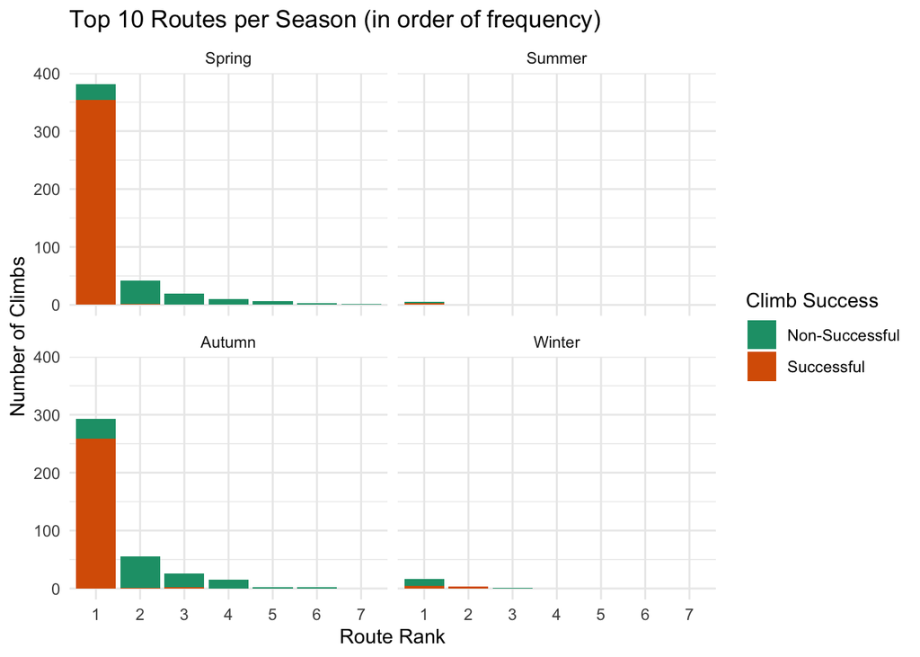

```r
data_top_routes <- exped_raw %>%
  count(SEASON,
        ROUTE1,
        TERMREASON) %>%
  group_by(SEASON,
           ROUTE1,
           TERMREASON) %>%
  summarise(n = sum(n),
            .groups = "drop") %>%
  arrange(SEASON,
          desc(n)) %>%
  group_by(SEASON,
           ROUTE1) %>%
  slice_max(order_by = n,
            n = 10) %>%
  mutate(rank = row_number()) %>%
  ungroup()

ggplot(data_top_routes,
       aes(x = factor(rank),
           y = n, fill = as.factor(TERMREASON == 1))) +
  geom_bar(stat = "identity") +
  facet_wrap(~SEASON, labeller = as_labeller(c("1" = "Spring",
                                               "2" = "Summer",
                                               "3" = "Autumn",
                                               "4" = "Winter"))) +
  scale_fill_brewer(palette = "Dark2",
                    labels = c("Non-Successful",
                               "Successful")) +
  labs(title = "Top 10 Routes per Season (in order of frequency)",
       x = "Route Rank",
       y = "Number of Climbs",
       fill = "Climb Success"
  ) +
  theme_minimal()
```

Looking at the data, Autumn and Spring seem to be the most frequently trekked seasons, with the most popular routes for the seasons being:

1. `S Col-SE Ridge`
2. `SW Ridge`
3. `NE Face`

[figure not shown]

```r
data <- exped_raw %>%
  filter(TERMREASON != 1) %>%
  count(SEASON,
        TERMREASON) %>%
  group_by(SEASON) %>%
  mutate(percentage = n / sum(n) * 100) %>%
  arrange(SEASON,
          desc(percentage)) %>%
  mutate(TERMREASON = as.character(TERMREASON)) %>%
  mutate(rank = row_number()) %>%
  mutate(TERMREASON = ifelse(rank > 4, "Other",
                             TERMREASON)) %>%
  group_by(SEASON,
           TERMREASON) %>%
  summarise(n = sum(n),
            percentage = sum(percentage),
            .groups = "drop") %>%
  mutate(TERMREASON = factor(TERMREASON))
# Plot
ggplot(data, aes(x = 1,
                 y = percentage,
                 fill = TERMREASON)) +
  geom_bar(stat = "identity", width = 1, color = "black") +
  coord_polar(theta = "y") +
  facet_wrap(~SEASON,
             labeller = as_labeller(c("1" = "Spring",
                                      "2" = "Summer",
                                      "3" = "Autumn",
                                      "4" = "Winter"))) +
  scale_fill_brewer(palette = "Dark2") +
  labs(
    title = "Top 7 Termination Reasons per Season (Others Grouped)",
    x = NULL,
    y = NULL,
    fill = "Termination Reason"
  ) +
  theme_void()
```

## Discussion

Several sources suggest that the commercialization of mountaineering has significantly influenced the choice of routes. As guided expeditions have become more common, an increasing number of climbers opt for well-established and popular routes rather than exploring new approaches. This uneven distribution of trek approaches is likely driven by the fact that commercial expeditions prioritize safer, more predictable routes to maximize client success rates and profitability. Finding unique or first-ascent routes has become less common, as these paths pose greater risks, require advanced skills, and are not as financially viable for guided services.

Additionally, commercialization has lowered the barrier to entry for less-experienced climbers, who often rely on guided tours rather than personal expertise. This shift likely explains the decline in new exploratory climbs, as many participants prioritize well-documented routes that offer a higher probability of reaching the summit. The presence of more novice climbers may also contribute to higher termination rates, as they are more susceptible to altitude sickness, fatigue, and extreme weather conditions.

## References

Works Cited

- Himalayan Expedition Database (TidyTuesday 2025-01-21). GitHub, https://github.com/rfordatascience/tidytuesday. Accessed 18 Mar. 2025.
- Wikipedia contributors. “Himalayan Mountaineering.” Wikipedia, The Free Encyclopedia, 2024, https://en.wikipedia.org/wiki/Mountaineering_in_the_Himalayas. Accessed 19 Mar. 2025.
- Horrell, Mark. “Two Great Histories of Himalayan Mountaineering.” Mark Horrell Blog, 2013, https://www.markhorrell.com/blog/2013/two-great-histories-of-himalayan-mountaineering/. Accessed 20 Mar. 2025.
- “Style Matters.” Mountain Athlete, https://mtnath.com/style-matters/. Accessed 17 Mar. 2025.
- “Himalayas and Climate Change.” Climate Change GPS, https://pressbooks.pub/climatechangegps/chapter/himalayas/#:~:text=During%20colder%20months%2C%20the%20wind,separate%20times%20of%20the%20year. Accessed 21 Mar. 2025.
- “Himalayan Weather and Climate.” Himalayan Wonders, https://www.himalayanwonders.com/blog/weather-climate-himalayas.html. Accessed 19 Mar. 2025.
- The Data Digest. “Exploring the Himalayan Expedition Database.” YouTube, uploaded by The Data Digest, https://www.youtube.com/watch?v=AHRh4yyHl4g&ab_channel=TheDataDigest. Accessed 20 Mar. 2025.
- “Forcats Reference: fct_lump.” Tidyverse, https://forcats.tidyverse.org/reference/fct_lump.html. Accessed 18 Mar. 2025.